# Chapter 3 - Introducing the Multilevel Model for Change

# What is the Purpose of the Multilevel Model for Change?

Statistical models are statements about the population process that generated the data.

A statistical model of change must specify (1) a level-1 submodel that describes how individuals change over time; and (2) a level-2 submodel that describes how these changes vary across individuals.

```r
library(tidyverse)

early.int <-
  tibble(id = rep(c(68, 70:72, 902, 904, 906, 908), each = 3),
         age = rep(c(1, 1.5, 2), times = 8),
         cog = c(103, 119, 96, 106, 107, 96, 112, 86, 73, 100, 93, 87,
                     119, 93, 99, 112, 98, 79, 89, 66, 81, 117, 90, 76),
         program = rep(1:0, each = 12))

print(early.int)

early.int <-
  early.int %>%
  mutate(age_c = age - 1)

# simulate data
# how many people are we simulating?
n <- 103 - 8

# what's the variance/covariance matrix?
sigma <- matrix(c(124.64, -36.41,
                  -36.41, 12.29),
                ncol = 2)

# what's our mean structure?
mu <- c(0, 0)

# set the seed and simulate!
set.seed(3)
z <-
  MASS::mvrnorm(n = n, mu = mu, Sigma = sigma) %>%
  data.frame() %>%
  set_names("zeta_0", "zeta_1")

head(z)

g <-
  tibble(id = 1:n,
         gamma_00 = 107.84,
         gamma_01 = 6.85,
         gamma_10 = -21.13,
         gamma_11 = 5.27)

head(g)

# set the seed for the second `mutate()` line
set.seed(3)

early.int.sim <-
  bind_cols(g, z) %>%
  mutate(program = rep(1:0, times = c(54, 41))) %>%
  expand(nesting(id, gamma_00, gamma_01, gamma_10, gamma_11, zeta_0, zeta_1, program),
         age_c = c(0, 0.5, 1)) %>%
  mutate(epsilon = rnorm(n(), mean = 0, sd = sqrt(74.24))) %>%
  mutate(pi_0 = gamma_00 + gamma_01 * program + zeta_0,
         pi_1 = gamma_10 + gamma_11 * program + zeta_1) %>%
  mutate(cog = pi_0 + pi_1 * age_c + epsilon)

head(early.int.sim)

early.int.sim <-
  early.int.sim %>%
  mutate(age = age_c + 1,
         cog = round(cog, digits = 0),
         id  = ifelse(id > 54, id + 900, id))

head(early.int.sim)

early.int.sim <-
  early.int.sim %>%
  select(id, age, cog, program, age_c) %>%
  full_join(early.int,
            by = c("id", "age", "cog", "program", "age_c")) %>%
  arrange(id, age)

glimpse(early.int.sim)
```

[output not shown]

# The Level-1 Submodel for Individual Change

The level-1 component of the multilevel model, or individual growth model, represents the change we expect each member of the population to experience during the time period under study.

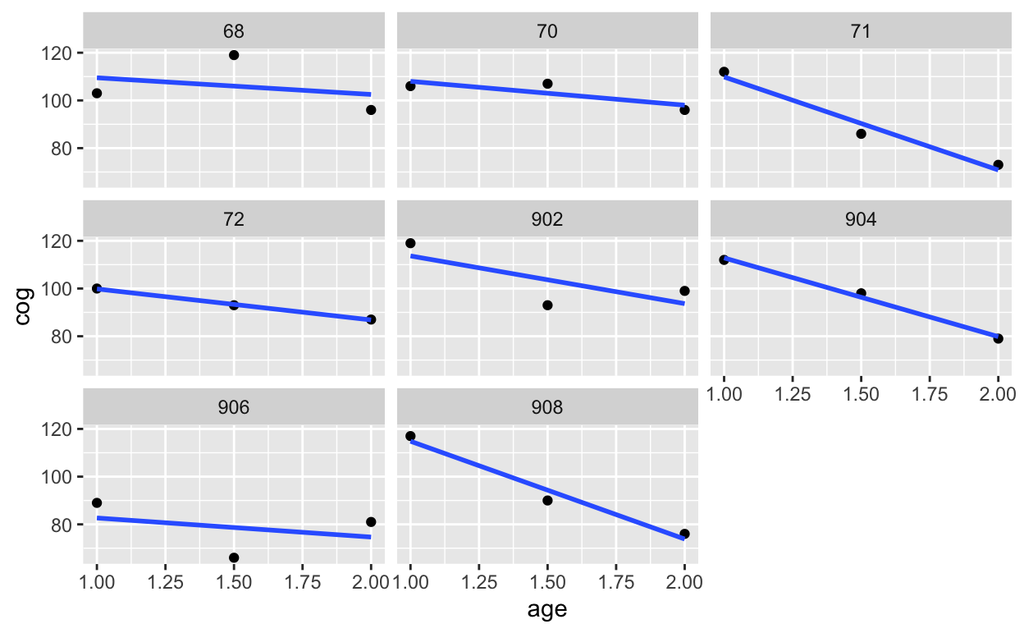

## The Structural Part of the Level-1 Submodel

We will estimate the following model:
$$\begin{aligned}
\pi_{0i} &= \gamma_{00} + \gamma_{01} \text{Program}_i + \epsilon_{0i} \\
\pi_{1i} &= \gamma_{10} + \gamma_{11} \text{Program}_i + \epsilon_{1i} \\
\end{aligned}$$

$\gamma_{01}$ and $\gamma_{11}$ capture the effects of the program. $\gamma_{01}$ represents the the hypothesized difference in average true initial status between groups; $\gamma_{11}$ represents the hypothesized differences in average true annual rate of change. These level-2 parameters therefore address the question: What is the difference in the average trajectory of true change associated with program participation?

## The Structural Components of the Level-2 Submodel

# Fitting the Multilevel Model for Change to Data

# Examining Estimated Fixed Effects

## Interpreting Estimated Fixed Effects

```r
print(fit3.2)
```

[output not shown]

```
 Family: gaussian
  Links: mu = identity; sigma = identity
Formula: cog ~ 0 + Intercept + age_c * program + (1 + age_c | id)
   Data: early.int.sim (Number of observations: 309)
Samples: 4 chains, each with iter = 2000; warmup = 1000; thin = 1;
         total post-warmup samples = 4000

Group-Level Effects:
~id (Number of levels: 103)
                     Estimate Est.Error l-95% CI u-95% CI Rhat Bulk_ESS Tail_ESS
sd(Intercept)            9.63      1.18     7.43    12.06 1.00     1026     1880
sd(age_c)                3.83      2.33     0.17     8.57 1.01      410     1002
cor(Intercept,age_c)    -0.45      0.38    -0.96     0.65 1.00     2879     1575

Population-Level Effects:
              Estimate Est.Error l-95% CI u-95% CI Rhat Bulk_ESS Tail_ESS
Intercept       106.65      1.88   102.87   110.29 1.00     1449     1946
age_c           -20.62      1.93   -24.47   -16.82 1.00     2958     2786
program           8.99      2.48     4.19    13.80 1.00     1440     2122
age_c:program     3.37      2.55    -1.72     8.29 1.00     2965     3170

Family Specific Parameters:
      Estimate Est.Error l-95% CI u-95% CI Rhat Bulk_ESS Tail_ESS
sigma     8.60      0.51     7.58     9.58 1.00      955     1538

Samples were drawn using sample(hmc). For each parameter, Bulk_ESS
and Tail_ESS are effective sample size measures, and Rhat is the potential
scale reduction factor on split chains (at convergence, Rhat = 1).
```

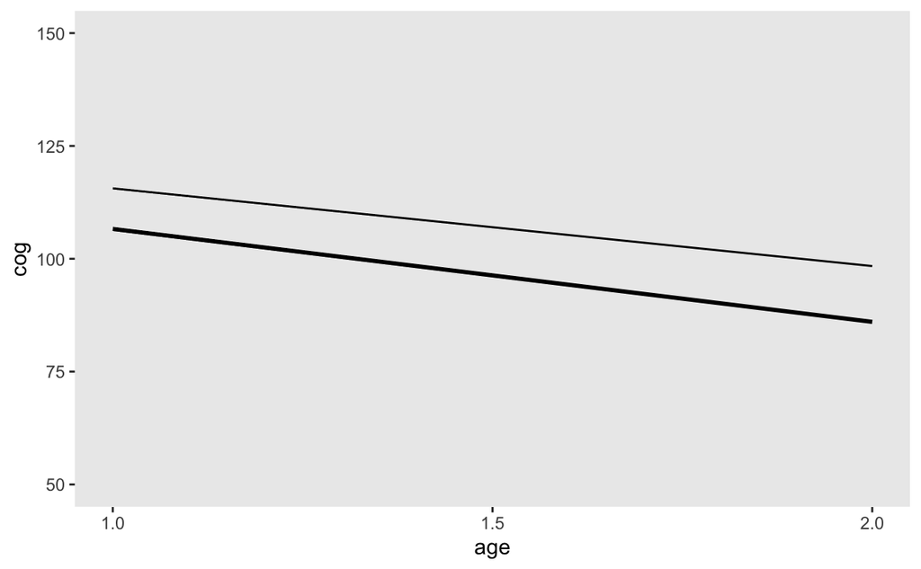

```r
# specify the values for our covariates `age_c` and `program`
crossing(age_c = 0:1,
         program = 0:1) %>%
  # push those values through the fixed effects
  mutate(cog = fixef(fit3.2)[1, 1] + fixef(fit3.2)[2, 1] * age_c + fixef(fit3.2)[3, 1] * program + fixef(fit3.2)[4, 1] * age_c * program,
         # wrangle a bit
         age = age_c + 1,
         size = ifelse(program == 1, 1/5, 3),
         program = factor(program, levels = c("0", "1"))) %>%

  # plot!
ggplot(aes(x = age, y = cog, group = program)) +
  geom_line(aes(size = program)) +
  scale_size_manual(values = c(1, 1/2)) +
  scale_x_continuous(breaks = c(1, 1.5, 2)) +
  ylim(50, 150) +
  theme(legend.position = "none",
        panel.grid = element_blank())
```